# Week 3 Homework

Charles-William Ruel

17NOV26

# Homework 3

Develop working knowledge of linear models in R: fitting them, reading diagnostic plots, and judging when a model is (or is not) correctly specified.

## Part A: Simulation Foundation

### Question 1

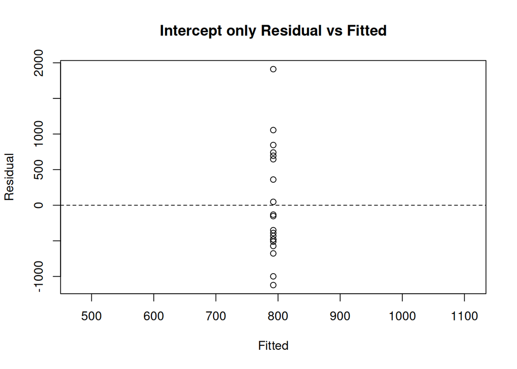

```r
set.seed(1234)
x <- 1:20
y <- 20+10*1:20+5*(1:20)^2+rnorm(20,0,200)

df <- data.frame(
  X = x,
  Y = y
)

lm.intOnly <- lm(Y~1, data=df)
lm.linear <- lm(Y ~ X, data=df)
lm.para <- lm(Y ~ X + I(X^2), data=df)

intOnly.pred <- predict(lm.intOnly)
linear.pred <- predict(lm.linear)
para.pred <- predict(lm.para)

intOnly.resid <- residuals(lm.intOnly)
linear.resid <- residuals(lm.linear)
para.resid <- residuals(lm.para)

plot(intOnly.pred, intOnly.resid, xlab="Fitted", ylab="Residual", main="Intercept only Residual vs Fitted")
abline(h=0,lty=2)
```

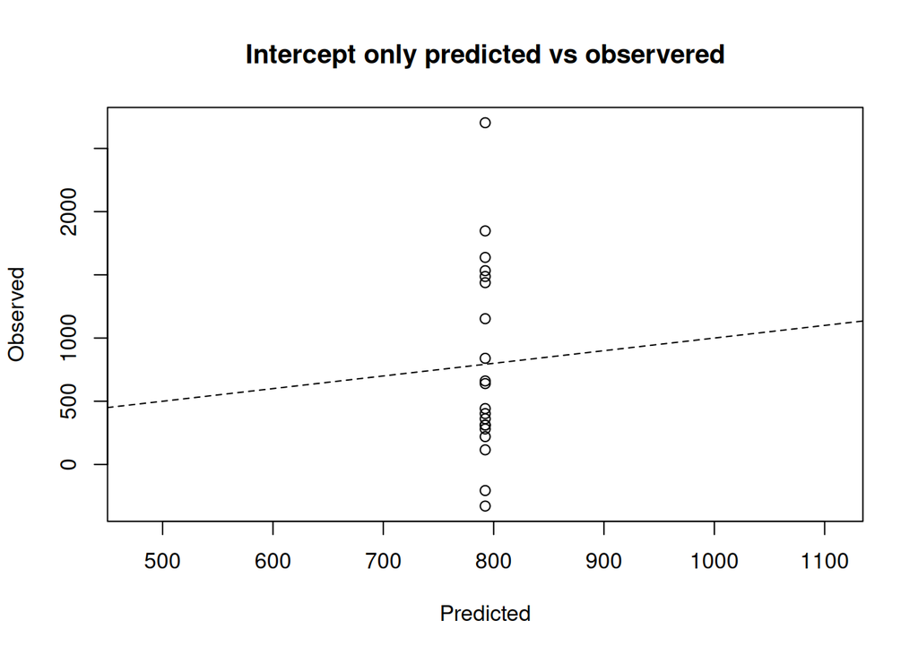

```r
plot(intOnly.pred, df$Y, xlab="Predicted", ylab="Observed", main="Intercept only predicted vs observered")
abline(0,1,lty=2)
```

The model created by fitting Y observations to only the intercept does not produce a very good model. We can determine this by observing the lack of fit to the Predicted:Observed dashed line in the predicted vs observed plot.

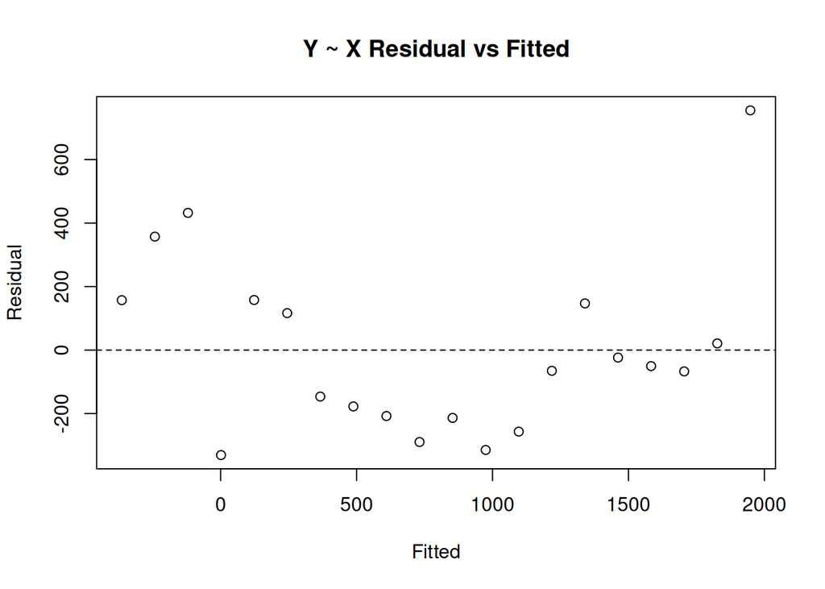

```r
plot(linear.pred, linear.resid, xlab="Fitted", ylab="Residual", main="Y ~ X Residual vs Fitted")
abline(h=0,lty=2)
```

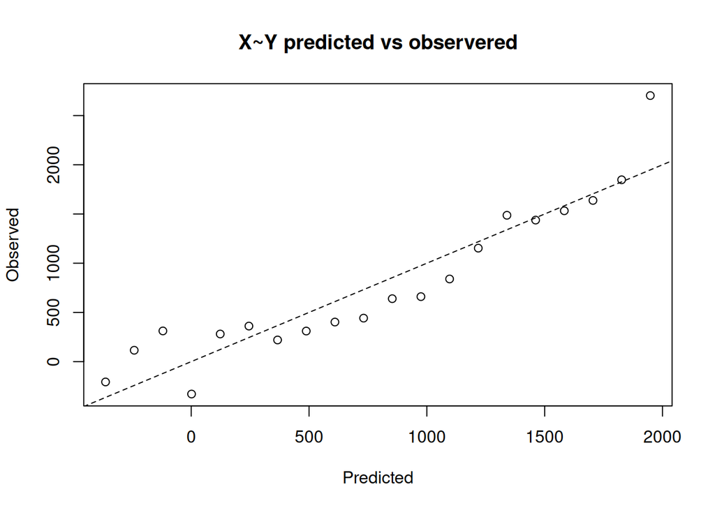

```r
plot(linear.pred, df$Y, xlab="Predicted", ylab="Observed", main="X~Y predicted vs observered")
abline(0,1,lty=2)
```

In the model created by fitting Y observations to X, we get a much better model compared to just fitting to intercept. As we can observe, the observed vs predicted plots fall closer to the y=x diagonal line compared to before.

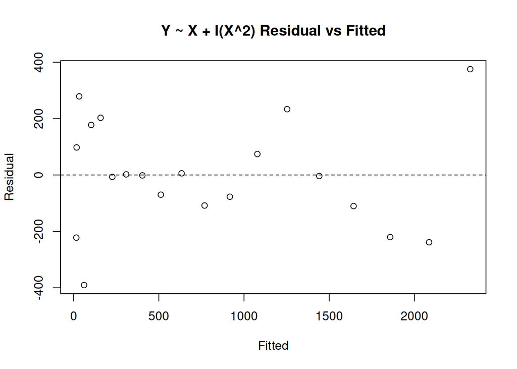

```r
plot(para.pred, para.resid, xlab="Fitted", ylab="Residual", main="Y ~ X + I(X^2) Residual vs Fitted")
abline(h=0,lty=2)
```

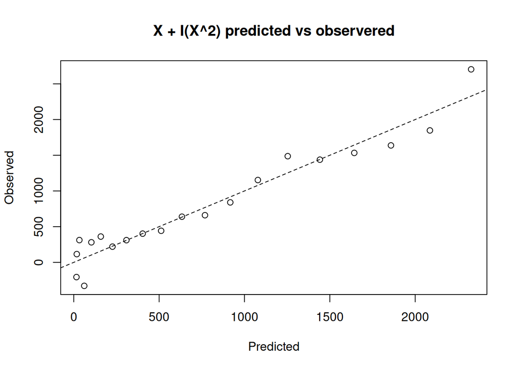

```r
plot(para.pred, df$Y, xlab="Predicted", ylab="Observed", main="X + I(X^2) predicted vs observered")
abline(0,1,lty=2)
```

```r
A <- coef(lm.para)["I(X^2)"]
B <- coef(lm.para)["X"]
C <- coef(lm.para)["(Intercept)"]
```